# ANOVA Conditions

September 16, 2021

## Announcements

- HW2 due Friday 9/17 11:55p
- In-person Office hours (Bass 412)
  - Thurs 1:20-2:35p
  - or by appointment!
- Zoom Office hours
  - Full for this week
- Where to get HW help
  - [Spinelli center](https://www.smith.edu/qlc/tutoring.html) tutoring Sun-Thurs 7-9p, Sabin-Reed 301.

## Review of last class

- Introduced the motivation behind the Analysis of Variance (ANOVA)
- Data decomposition
- Computing the SS, MS, df, and F-ratio
- Inference for ANOVA (p-values)

## ANOVA for One-Way ANOVA

Model:

\[{y}_{ij}=\mu+{\alpha}_{i}+{e}_{ij}\]

Null hypothesis:

\[{H}_{0}:{\alpha}_{1}={\alpha}_{2}=...={\alpha}_{a}\]

ANOVA Source table:

| Source | SS | df | MS | F |
| --- | --- | --- | --- | --- |
| Treatment | \(n\sum_{i=1}^{a}(\bar{y}_{i.}-\bar{y}_{..})^{2}\) | \(a-1\) | \(\frac{{SS}_{Treatments}}{{df}_{Treatments}}\) | \(\frac{{MS}_{Treatments}}{{MS}_{E}}\) |
| Error | \(\sum_{i=1}^{a}\sum_{j=1}^{n}({y}_{ij}-\bar{y}_{i.})^{2}\) | \(N-a\) | \(\frac{{SS}_{E}}{{df}_{E}}\) |  |

## Running an ANOVA in R

1. Boxplots or some data visualization
2. Descriptive statistics (n, means, standard deviations)
3. ANOVA
4. Check assumptions

## Step 1. Boxplots

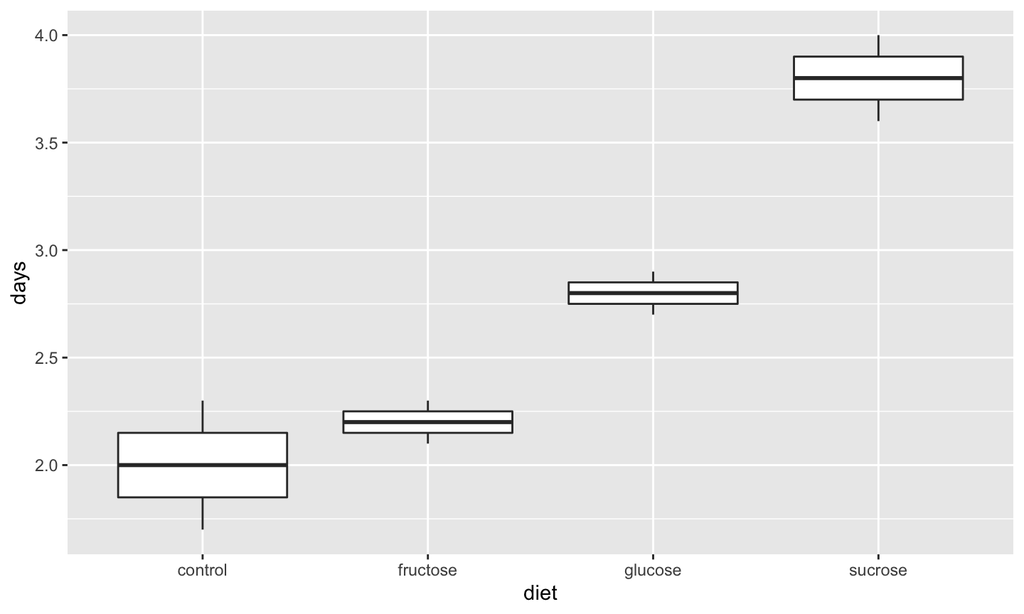

```r
#Note that boxplots are a bit silly in this example because n is only 2.
qplot(x = diet, y = days, data = leaf, geom = "boxplot")
```

## Step 2. Descriptive Statistics

```r
leaf %>%
  group_by(diet) %>%
  summarize(n = n(),
            m = mean(days),
            sd = sd(days))
```

```
## # A tibble: 4 x 4
##   diet         n     m    sd
##   <chr>    <int> <dbl> <dbl>
## 1 control      2   2   0.424
## 2 fructose     2   2.2 0.141
## 3 glucose      2   2.8 0.141
## 4 sucrose      2   3.8 0.283
```

## Step 3. ANOVA

```r
mod <- lm(days ~ diet, data = leaf)
anova(mod)
```

```
## Analysis of Variance Table
##
## Response: days
##           Df Sum Sq Mean Sq F value   Pr(>F)
## diet       3   3.92  1.3067  17.422 0.009248 **
## Residuals  4   0.30  0.0750
## ---
## Signif. codes:  0 '***' 0.001 '**' 0.01 '*' 0.05 '.' 0.1 ' ' 1
```

### Write a sentence interpreting the One-Way ANOVA results

There are statistically significant differences in leafhopper survival rates across diets, \(F(3, 4) = 17.42\), \(p = .009\).

**OR**

Diet has a statistically significant effect on leafhopper survival rates, \(F(3, 4) = 17.42\), \(p = .009\).

## Try it!

In groups of three run all three steps (visualize, descriptive stats, and ANOVA) for the two datasets below. Write a sentence about your conclusion from the ANOVA.

**Dataset 1**: `SandwichAnts`

- Factor: `Bread`
- Response: `Ants`

**Dataset 2**: `Meniscus`

- Factor: `Method`
- Response: `Displacement`

```r
library(Stat2Data)
data("SandwichAnts")
?SandwichAnts
```

## ANOVA Conditions

**STOP!!**…only under certain conditions can we rely on this inference. There were many assumptions built into:

- how we decomposed the data, and
- our thoughts about residual errors.

### Simulation in R: Assembly Line Metaphor

[figure not shown]

- Recall the [Assembly Line Metaphor code](https://randilgarcia.github.io/sds290fall21/lectures/02_informal_anova.Rmd)

## ANOVA Conditions

- **C**. Constant effects
- **A**. Additive effects
- **S**. Same standard deviations
- **I**. Independent residuals
- **N**. Normally distributed residuals
- **Z**. Zero mean residuals

## C. Constant effects

We assume every observation in a similar condition is affected exactly the same. (Gets the same “true score”).

```r
animals_sim <- animals %>%
  mutate(benchmark = mean(calm)) %>%
  group_by(animal) %>%
  mutate(animal_mean = mean(calm),
         aminal_effect = animal_mean - benchmark)
```

## A. Additive effects

We add the effects as we go down the assembly line.

The interaction effect captures the possibility that conditions have non-additive effects, but it is also added to everything else.

```r
calm_sim = benchmark
         + aminal_effect
         + cue_effect
         + interaction_effect
         + student_effect
```